# Lab 06 TensorFlow Datasets

In this reading notebook, we will take a look at the `tensorflow-datasets` library.

We have previously made use of the `tf.keras.datasets` package, which gave us access to a variety of useful datasets such as the IMDB movie dataset, the CIFAR-100 small image classification dataset, and the MNIST handwritten digits dataset.

The `tensorflow-datasets` library gives us another means of accessing a variety of useful datasets.

## Installation

The `tensorflow-datasets` library is installed independently of TensorFlow itself. It can be installed using pip, by running the following command in a terminal (assuming that `tensorflow` has already been installed):

`pip install tensorflow-datasets`

## Listing the Available Datasets

The `list_builders` function can be used to list the available datasets.

```python
# List available datasets
import tensorflow_datasets as tfds
tfds.list_builders()
```

```
['abstract_reasoning',
 'aflw2k3d',
 'amazon_us_reviews',
 'bair_robot_pushing_small',
 'bigearthnet',
 'binarized_mnist',
 'binary_alpha_digits',
 'caltech101',
 'caltech_birds2010',
 'caltech_birds2011',
 'cats_vs_dogs',
 'celeb_a',
 'celeb_a_hq',
 'chexpert',
 'cifar10',
 'cifar100',
 'cifar10_corrupted',
 'clevr',
 'cnn_dailymail',
 'coco',
 'coco2014',
 'coil100',
 'colorectal_histology',
 'colorectal_histology_large',
 'curated_breast_imaging_ddsm',
 'cycle_gan',
 'deep_weeds',
 'definite_pronoun_resolution',
 'diabetic_retinopathy_detection',
 'downsampled_imagenet',
 'dsprites',
 'dtd',
 'dummy_dataset_shared_generator',
 'dummy_mnist',
 'emnist',
 'eurosat',
 'fashion_mnist',
 'flores',
 'food101',
 'gap',
```

[output cut: 46 more lines]

```
 'trivia_qa',
 'uc_merced',
 'ucf101',
 'visual_domain_decathlon',
 'voc2007',
 'wikipedia',
 'wmt14_translate',
 'wmt15_translate',
 'wmt16_translate',
 'wmt17_translate',
 'wmt18_translate',
 'wmt19_translate',
 'wmt_t2t_translate',
 'wmt_translate',
 'xnli']
```

## Loading a Dataset

Loading a particular dataset is straightforward; simply use the `load` function, specifying the `name` and any other keyword arguments. In the example code below, we demonstrate how to load the `kmnist` dataset using the function.

As stated on the documentation page, running the function with `split=None` (the default) returns a dictionary of the splits, with the keys `test` and `train`.

```python
# Load the mnist_corrupted dataset
kmnist  = tfds.load(name = 'kmnist', split = None)
kmnist_train = kmnist['train']
kmnist_test = kmnist['test']
```

```
WARNING:absl:Warning: Setting shuffle_files=True because split=TRAIN and shuffle_files=None. This behavior will be deprecated on 2019-08-06, at which point shuffle_files=False will be the default for all splits.
```

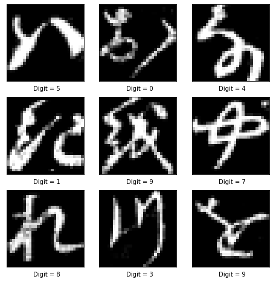

```python
# View some examples from the dataset

import matplotlib.pyplot as plt
%matplotlib inline
import tensorflow as tf

fig, axes = plt.subplots(3, 3, figsize = (8, 8))
fig.subplots_adjust(hspace = 0.2, wspace = 0.1)

for i, (elem, ax) in enumerate(zip(kmnist_train, axes.flat)):
    image = tf.squeeze(elem['image'])
    label = elem['label']

    ax.imshow(image, cmap = 'gray')
    ax.text (
        0.7, -0.12, f'Digit = {label}', ha = 'right',
        transform = ax.transAxes, color = 'black'
    )
    ax.set_xticks([])
    ax.set_yticks([])
```

## Further reading and resources

- https://www.tensorflow.org/datasets
- https://www.tensorflow.org/datasets/catalog/overview
- https://wwww.tensorflow.org/datasets/api_docs/python/tfds
- https://tensorflow.org/datasets/api_docs/python/tfds/load